# R Notebook

## Import

This step could be reading a file, or loading an R package dataset into a variable.

```r
df <- titanic_train

df
```

| PassengerId | Survived | Pclass | Name | Sex | Age | SibSp | Parch | Ticket | Fare | Cabin | Embarked |
| --- | --- | --- | --- | --- | --- | --- | --- | --- | --- | --- | --- |
| 1 | 0 | 3 | Braund, Mr. Owen Harris | male | 22.00 | 1 | 0 | A/5 21171 | 7.2500 |  | S |
| 2 | 1 | 1 | Cumings, Mrs. John Bradley (Florence Briggs Thayer) | female | 38.00 | 1 | 0 | PC 17599 | 71.2833 | C85 | C |
| 3 | 1 | 3 | Heikkinen, Miss. Laina | female | 26.00 | 0 | 0 | STON/O2. 3101282 | 7.9250 |  | S |
| 4 | 1 | 1 | Futrelle, Mrs. Jacques Heath (Lily May Peel) | female | 35.00 | 1 | 0 | 113803 | 53.1000 | C123 | S |
| 5 | 0 | 3 | Allen, Mr. William Henry | male | 35.00 | 0 | 0 | 373450 | 8.0500 |  | S |
| 6 | 0 | 3 | Moran, Mr. James | male | NA | 0 | 0 | 330877 | 8.4583 |  | Q |
| 7 | 0 | 1 | McCarthy, Mr. Timothy J | male | 54.00 | 0 | 0 | 17463 | 51.8625 | E46 | S |
| 8 | 0 | 3 | Palsson, Master. Gosta Leonard | male | 2.00 | 3 | 1 | 349909 | 21.0750 |  | S |
| 9 | 1 | 3 | Johnson, Mrs. Oscar W (Elisabeth Vilhelmina Berg) | female | 27.00 | 0 | 2 | 347742 | 11.1333 |  | S |
| 10 | 1 | 2 | Nasser, Mrs. Nicholas (Adele Achem) | female | 14.00 | 1 | 0 | 237736 | 30.0708 |  | C |

[output cut: 881 more lines]

## Tidy & transform

```r
tidy_df <- df %>%
  filter(!is.na(Age)) %>%
  mutate(is_female = ifelse(Sex == "female", 0, 1)) %>%
  select(
    -Ticket,
    -Cabin,
    -Sex,
    -PassengerId,
    -Name
  ) %>%
  rename_all(tolower)

glimpse(tidy_df)
```

```
Observations: 714
Variables: 8
$ survived  <int> 0, 1, 1, 1, 0, 0, 0, 1, 1, 1, 1, 0, 0, 0, 1, 0, 0, 0,...
$ pclass    <int> 3, 1, 3, 1, 3, 1, 3, 3, 2, 3, 1, 3, 3, 3, 2, 3, 3, 2,...
$ age       <dbl> 22, 38, 26, 35, 35, 54, 2, 27, 14, 4, 58, 20, 39, 14,...
$ sibsp     <int> 1, 1, 0, 1, 0, 0, 3, 0, 1, 1, 0, 0, 1, 0, 0, 4, 1, 0,...
$ parch     <int> 0, 0, 0, 0, 0, 0, 1, 2, 0, 1, 0, 0, 5, 0, 0, 1, 0, 0,...
$ fare      <dbl> 7.2500, 71.2833, 7.9250, 53.1000, 8.0500, 51.8625, 21...
$ embarked  <chr> "S", "C", "S", "S", "S", "S", "S", "S", "C", "S", "S"...
$ is_female <dbl> 1, 0, 0, 0, 1, 1, 1, 0, 0, 0, 0, 1, 1, 0, 0, 1, 0, 1,...
```

## Visualization

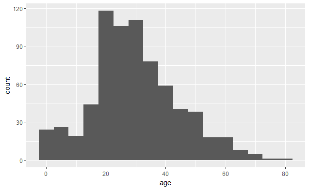

```r
library(ggplot2)

ggplot(data = tidy_df) +
  geom_histogram(aes(x = age), binwidth =  5)
```

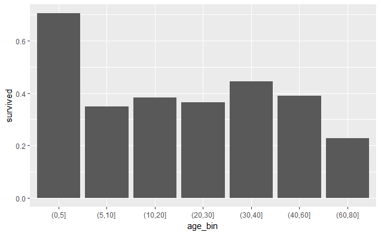

```r
tidy_df %>%
  mutate(age_bin = cut(age, breaks = c(0, 5, 10, 20, 30, 40, 60, 80))) %>%
  group_by(age_bin) %>%
  summarise(survived = sum(survived) / n()) %>%
  ggplot() +
  geom_col(aes(x = age_bin, y = survived))
```

## Model

```r
tidy_df %>%
  select(-embarked) %>%
  cor(.)
```

[output not shown]

```r
set.seed(100)

model_df <- tidy_df %>%
  select(
    -fare
  ) %>%
  sample_frac(0.8)

model1 <- glm(survived ~. , data = model_df)

summary(model1)
```

[output not shown]

```r
indices <- sample(1:nrow(tidy_df), size = 0.80 * nrow(tidy_df))
train <- tidy_df[indices, ]
test  <- tidy_df[-indices, ]

model_df <- train %>%
  select(
    -fare,
    -parch,
    -sibsp,
    -embarked
  ) %>%
  mutate(age = ifelse(age <= 5, 1, 0))

model2 <- glm(survived ~. , data = model_df)

summary(model2)
```

```
Call:
glm(formula = survived ~ ., data = model_df)

Deviance Residuals:
     Min        1Q    Median        3Q       Max
-1.26835  -0.23808  -0.05476   0.25334   0.94524

Coefficients:
            Estimate Std. Error t value Pr(>|t|)
(Intercept)  1.11330    0.04683  23.772  < 2e-16 ***
pclass      -0.18332    0.01907  -9.612  < 2e-16 ***
age          0.33837    0.06415   5.274  1.9e-07 ***
is_female   -0.50859    0.03291 -15.453  < 2e-16 ***
---
Signif. codes:  0 ‘***’ 0.001 ‘**’ 0.01 ‘*’ 0.05 ‘.’ 0.1 ‘ ’ 1

(Dispersion parameter for gaussian family taken to be 0.140362)

    Null deviance: 137.923  on 570  degrees of freedom
Residual deviance:  79.585  on 567  degrees of freedom
AIC: 505.24

Number of Fisher Scoring iterations: 2
```

```r
validation <- predict(model2, test)

val_df <- test %>%
  mutate(score = validation,
         prediction = ifelse(score < 0.7, 0, 1))


results <- val_df %>%
  group_by(
    survived,
    prediction
  ) %>%
  tally()

results
```

[output not shown]

## Appendix

Data Dictionary (source: Kaggle.com)

Variable Definition Key survival Survival 0 = No, 1 = Yes pclass Ticket class 1 = 1st, 2 = 2nd, 3 = 3rd sex Sex Age Age in years  
sibsp # of siblings / spouses aboard the Titanic  
parch # of parents / children aboard the Titanic  
ticket Ticket number  
fare Passenger fare  
cabin Cabin number  
embarked Port of Embarkation C = Cherbourg, Q = Queenstown, S = Southampton Variable Notes

pclass: A proxy for socio-economic status (SES) 1st = Upper 2nd = Middle 3rd = Lower

age: Age is fractional if less than 1. If the age is estimated, is it in the form of xx.5

sibsp: The dataset defines family relations in this way… Sibling = brother, sister, stepbrother, stepsister Spouse = husband, wife (mistresses and fiancés were ignored)

parch: The dataset defines family relations in this way… Parent = mother, father Child = daughter, son, stepdaughter, stepson Some children travelled only with a nanny, therefore parch=0 for them.